# PD3 Raport

Michał Klein, Szymon Kałużny

2023-03-29

# Analiza wyników ankiety dotyczącej odczytywania danych z różnych wykresów

## Krótki opis badania

W naszej pracy przeprowadziliśmy dwa eksperymenty badawcze, zbierając dane z ankiety przeprowadzonej na próbce 20 osób. Na ich podstawie wyciągnęliśmy wnioski z otrzymanych od respondentów wyników i informacji. W pierwszym eksperymencie skupiliśmy się na ukazaniu dwóch różnych typów wykresów, prezentujących te same dane, a następnie porównaliśmy ich czytelność. W drugim eksperymencie zajęliśmy się trudnościami związanymi z odpowiednią interpretacją wielkości w wykresach o zakresie osi Y niezaczynającym się w zerze. Oba eksperymenty zawierały po kilka pytań sprawdzających czy pytany potrafi odczytać daną informację z wykresu. Ponadto pytaliśmy również o subiektywną opinię nt. czytelności wizualizacji. Szczegółowe wyniki i wnioski płynące z analizy odpowiedzi uczestników przedstawimy w tym raporcie.

## Eksperyment 1

W pierwszym eksperymencie badaliśmy wpływ typu wykresu na odczyt wartości zmiennych. Najpierw pokazaliśmy uczestnikom wykres kołowy 3D:

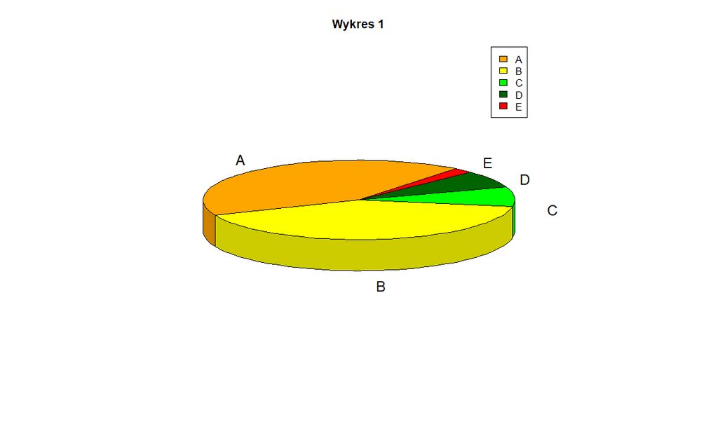

W oparciu o ten wykres zadaliśmy 3 pytania. Pierwsze dwa dotyczyły porównywania bliskich wartości dla zmiennych nominalnych A i B, oraz C i D. W trzecim pytaniu ankietowani musieli zdecydować, czy wartości zmiennych A, D i E dają większą sumę niż wartości B i C. Następnie przedstawiliśmy te same dane na wykresie słupkowym 2D (zachowując tę samą kolorystykę):

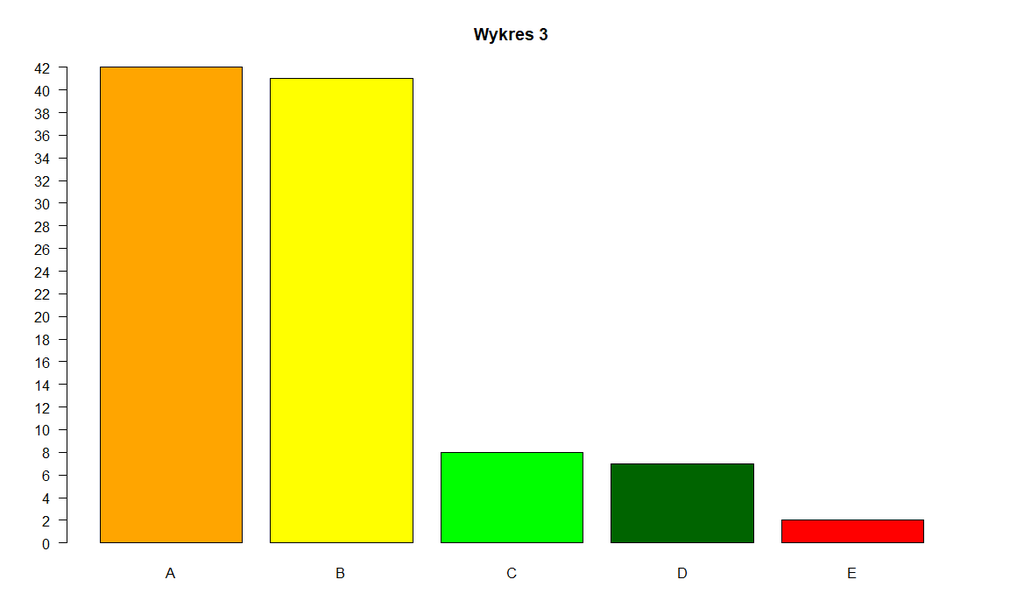

i zadaliśmy te same pytania. Odpowiedzi prezentują się w następujący sposób:

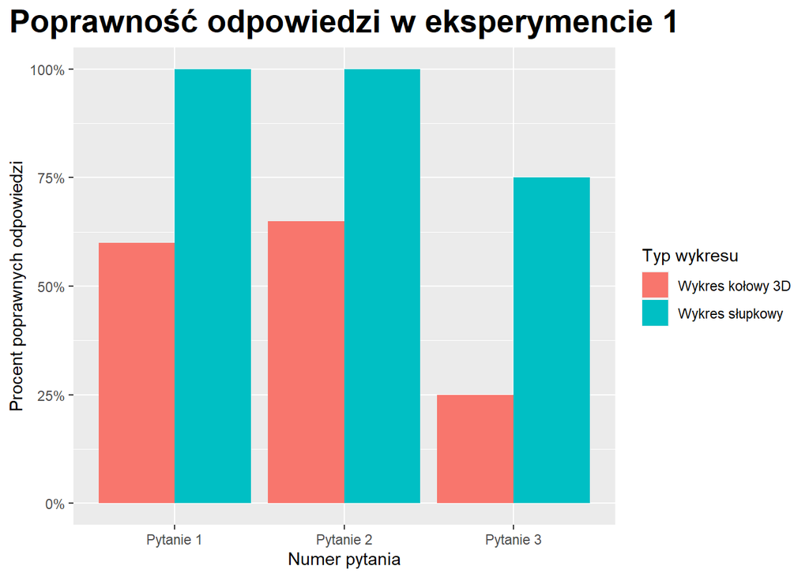

Z powyższego wykresu możemy odczytać, że w przypadku wykresu słupkowego ankietowani udzielali o wiele więcej poprawnych odpowiedzi, niż w przypadku trójwymiarowego wykresu kołowego. W przypadku porównywania pojedynczych wartości, nikt z pytanych 20 osób nie wskazał błędnej odpowiedzi. Zaś w przypadku wykresu kołowego niewiele ponad połowa ankietowanych odpowiedziała prawidłowo. Natomiast w przypadku pytania o sumy wartości zmiennych, błędy zdarzały się nawet przy wykresie słupkowym, jednakże znaczna większość odpowiedziała na to pytanie poprawnie. Natomiast trójwymiarowy wykres kołowy skutecznie zmylił 75% ankietowanych (warto wspomnieć, że aż 65% ankietowanych uważało, że sumy wartości A, D i E, oraz B i C są sobie równe). Możemy stąd wywnioskować, iż odczytywanie informacji z wykresu kołowego 3D rzeczywiście jest trudne i stanowi poważne problemy, natomiast porównywanie sum wartości kilku zmiennych jest już w praktyce awykonalne. Inaczej ma się rzecz z wykresem słupkowym, który jest przejrzysty i porównywanie wartości pojedynczych zmiennych nie sprawia problemów. Jeżeli chodzi o przyrównywanie sum kilku zmiennych, to jest to trudniejsze do odczytania, ale i tak więcej respondentów zrobiło to poprawnie, niż w przypadku wykresu kołowego 3D. Stąd nasuwa się wniosek, że wyniki są takie, gdyż przedstawienie obiektu trójwymiarowego na płaskim ekranie zaburza proporcje. Dodatkowo wykres kołowy, gdzie dominującą rolę w odczytywaniu wartości grają kąty, potęguje ten efekt. Zatem ogólnie rzecz ujmując wykresy słupkowe dwuwymiarowe są czytelniejsze dla zmiennych przedziałowych, tzn. różnice pomiędzy wartościami są lepiej widoczne.

## Eksperyment 2

### Część 1

W kolejnym eksperymencie badaliśmy wpływ manipulacji zakresu i skali wartości na osi na analizę wykresu przez czytelników. Okazaliśmy uczestnikom badania wykres z przesuniętą osią Y:

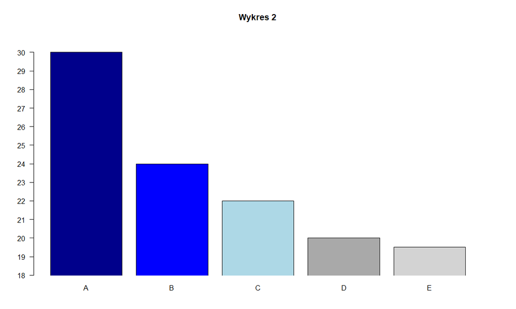

i ponownie zapytaliśmy o porównanie sum. W tym przypadku pytaliśmy, czy suma wartości D i E jest większa od wartości C. Po udzieleniu odpowiedzi ankietowanym został ukazany wykres z osią Y zaczynającą się w 0, po czym zostali oni poproszeni o odpowiedź na to samo pytanie.

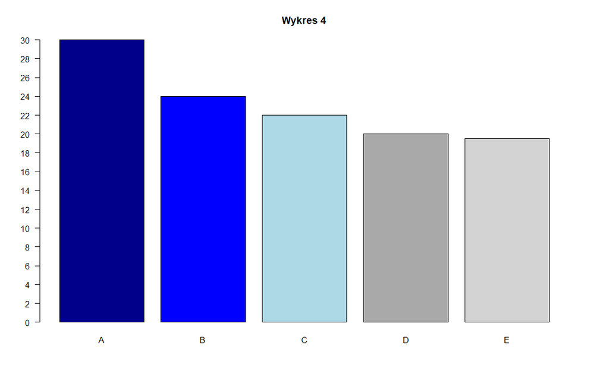

Ankieta wykazała że odpowiedzi były zróżnicowane w przypadku pierwszego wykresu z tego eksperymentu.

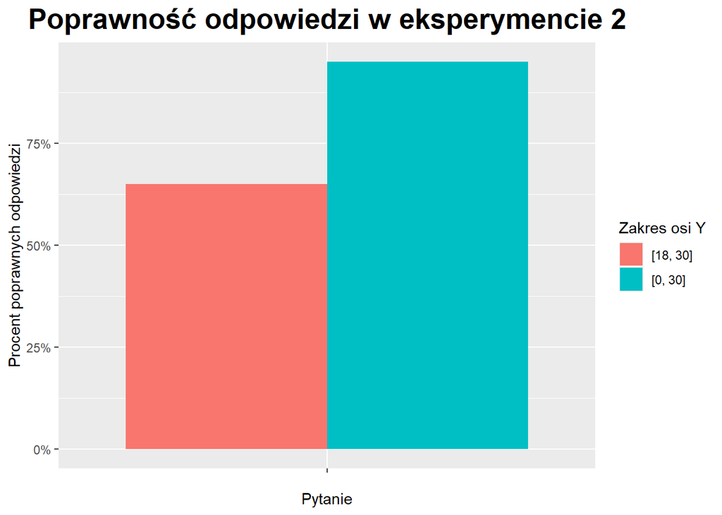

Ponad 1/3 badanych udzieliła błędnej odpowiedzi, najprawdopodobniej podyktowanej geometrycznym podejściem szacowania wysokości słupków, co w przypadku wykresu o skali przesuniętej (bądź innego typu, np. logarytmicznej) prowadzi do przekłamań. Należy zatem dokładnie informować odbiorcę o użytej skali i jej zakresie widocznym na wykresie. Częste przeoczenia oglądających prowadzą do zmanipulowania dużej grupy odbiorców.

### Część 2

W tym eksperymencie zadaliśmy jeszcze jedno pytanie dotyczące tych dwóch wykresów. Było to pytanie otwarte. Zapytaliśmy ile razy wartość zmiennej A jest większa od wartości zmiennej B. Wyniki są zdumiewające:

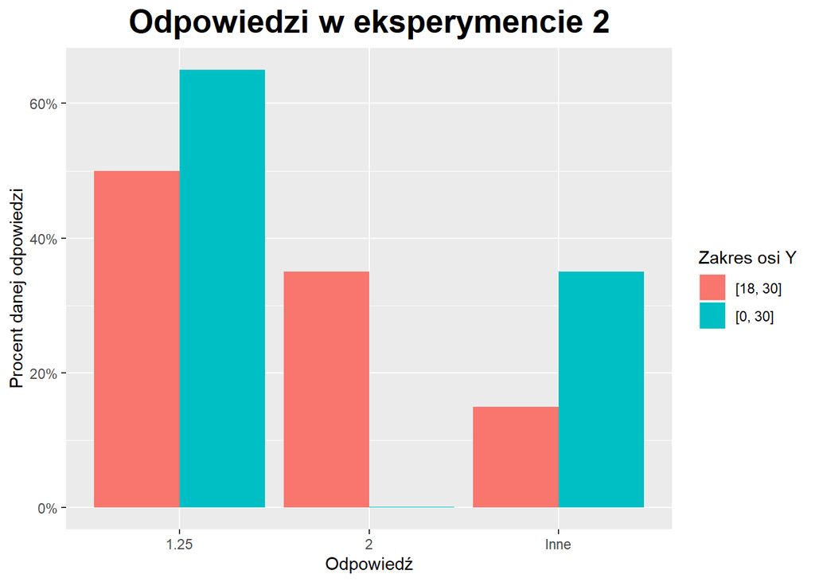

Na podstawie powyższej wizualizacji widzimy, że aż 35% badanych nie zwróciło uwagi na podziałkę osi Y i popełniło podobny błąd, co część osób w części 1. Co więcej, tylko połowa ankietowanych odczytała dane poprawnie. Statystyka jest lepsza w sytuacji standardowej podziałki. Natomiast martwiąca jest duża ilość odpowiedzi w kat. “Inne”, co może świadczyć o braku ogólnej umiejętności czytania wykresów (i/lub odpowiadania na pytania zaczynające się od słów “ile razy”) przez respondentów.

## Opinie uczestników o wykresach

Na koniec ankiety zestawiliśmy wykresy z pierwszego, a następnie z drugiego eksperymentu ze sobą, po czym zadaliśmy pytanie o subiektywną opinię ankietowanych na temat tego, który wykres jest, ich zdaniem, czytelniejszy i/lub łatwiejszy w odbiorze. W odpowiedziach na te pytania 100% ankietowanych podzieliło naszą opinię o lepszej jakości wykresu słupkowego 2D nad wykresem kołowym 3D. Jednak w przypadku eksperymentu drugiego ankietowani nie byli jednogłośni. Nawet po zestawieniu dwóch wykresów obok siebie, 10% pytanych osób stwierdziło, że czytelniejszy i/lub lepszy w odbiorze był wykres, który widzieli wcześniej, na którym oś Y zaczynała się od 18. Warto wspomnieć, że 2 osoby, które odpowiedziały w ten sposób na to pytanie, błędnie odpowiedziały na pytania dotyczące “manipulatywnego” wykresu (obie te osoby odpowiedziały, że wartość A jest dwukrotnie większa od wartości B, oraz że suma wartości D i E jest mniejsza od wartości C).

## Wnioski

1. Typ wykresu ma wpływ na jego czytelność.
- Wykresy 3D bez odpowiednich oznaczeń są mniej czytelne i gorzej postrzegane przez odbiorców.
- Niepodpisany wykres kołowy utrudnia porównywanie wartości dla danych zmiennych.
2. Skala i zakres podziałki mają wpływ na interpretację wykresu przez czytelnika.
- Łatwo zmanipulować opinię innych poprzez stosowanie zabiegu zmiany zakresu.
- Aby nie wprowadzać w błąd dobrze jest opisać że podziałka na skali Y nie jest standardowa (w przypadku zmiennych przedziałowych najlepiej zawsze zaczynać ją w zerze).